# H06 daily metrics — METRIC-010 MDER amendment

- Show All Code
- Hide All Code
- View Source

Preregistration-aligned participant-day analysis under the mean-of-viable-ratios rule

Published

August 11, 2026

**ImportantAnswer in brief**

Under the replacement METRIC-010 definition, the primary near-eye estimates were -0.0013 MDER for Free day minus Work day (95% CI -0.0134 to 0.0108), 0.0083 for Active minus Sedentary (-0.0070 to 0.0235), and 0.0017 per one hour greater previous-night sleep (-0.0028 to 0.0063). All three intervals include zero.

After the corrected gap-branch rebuild, the corresponding near-eye Gaussian estimates are -0.0016, 0.0090, and 0.0018; their 95% intervals also include zero. The mandatory Student-t sleep interval is only just above zero, which is reported as tail-model sensitivity rather than a multiplicity-based finding. The corrected gap samples contain 687 MDER days near eye and 723 at the chest, with no finite nonpositive value.

The work/free and sleep estimates remain reportable as magnitudes, but their directions reversed in at least one leave-one-site refit, so no stable cross-site directional claim is defensible. The activity direction was stable, but its generality is limited by site influence and all three Gaussian fits retain a heavy-tail limitation. The mandatory Student-t and actual-date AR(1) checks did not materially move the primary estimates.

These are **raw MDER-slot results only**. Each prespecified BH family currently contains one of 15 required metric slots, so no adjusted p-value or multiplicity-based decision exists. The associations are observational and do not support causal or health claims.

# 1 Scope and supersession rule

This amendment analyzes MDER only. All MDER-independent H06_daily work is frozen. No prior estimate, tail conclusion, device-day conclusion, or time-profile threshold result from the superseded ratio-of-integrals implementation is transferred.

The analysis unit is one admissible MDER-specific participant-day. Days are not weighted by supported hours or by the number of viable minutes beyond the admissibility threshold. This is the preregistration-aligned participant-day route, not the approved hourly H06 model and not the exploratory 30-minute GAMM.

# 2 Exact replacement metric and provenance

Daily MDER is the arithmetic mean of viable one-minute melEDI/illuminance ratios. A minute is viable only when both channels are finite and strictly positive. The upstream preparation uses a complete 1,440-minute local wall-clock grid, averages fall-back duplicate local minutes channel-wise before forming a ratio, and leaves spring-forward absent minutes missing. MDER is retained at **at least 720 viable ratios**, including exactly 720; otherwise MDER alone is missing. There is no profile weighting, gating, scaling, or ratio of daily integrals.

Table 1: Pinned controlling METRIC-010 inputs.

| Input | Path | SHA-256 | Verified |
| --- | --- | --- | --- |
| metric010_decision | audit/decisions/mder_mean_of_viable_ratios.md | 1664347de976057807fcb5ac6e24bd4b66af1fe32378fabd1f2acafcfc9266de | Yes |
| metric_manifest | artifacts/12_manifests/metric_artifacts.csv | 7bb2830c695e5600f0877acca500a187a040fe727a029bdb069f69099abe4f43 | Yes |
| mder_audit_manifest | artifacts/08_diagnostics/mder_METRIC-010/audit_manifest.csv | 5bd34fd4ac26dc2761540393d40e096cde835d8dd4b4edda9253243c9083d4bb | Yes |
| base_manifest | artifacts/12_manifests/base_model_data_artifacts.csv | b6fa22836faee5243bb6ce1cc9dceab5d5403f94d688f8f74472a19dbf6e3e09 | Yes |
| gap_manifest | artifacts/12_manifests/manuscript_prepared_data_artifacts.csv | 4ed62fbe58de65a6d05d8cfc6b5d870d7c74a3c83fe89bcd72bd1dd838698935 | Yes |
| h01_gap_manifest | artifacts/12_manifests/H01_manuscript_prepared_data_artifacts.csv | 79ee4818d7f3967827a6412f8537196e84ee7a6ccc1b8d2c5e9dd3124ed44b47 | Yes |
| gap_repair_evidence | audit/reconciliation/mder_METRIC-010_gap_repair/gap_repair_evidence_manifest.csv | 81e3aa9439b88cf239d6669dc4343cfb146cd2f45790bae412ab837156315018 | Yes |
| gap_participant_day | artifacts/06_model_data/scenarios/manuscript_prepared_data/participant_day_metrics.rds | 7561b5dd47cb5e23ca94ba59bd57648f11fe492f86af53a566c5c9cf42d932f1 | Yes |
| gap_mder_support | artifacts/06_model_data/scenarios/manuscript_prepared_data/mder_support.rds | a0bc5d7ea2142709412da2253158086416ddb730b0f60ff616bba9d6ccb1edc5 | Yes |

# 3 Metric availability and exact fitted samples

Table 2: METRIC-010 availability before predictor-specific complete-case selection.

| Dataset | Placement | Available days | Participants with MDER | Sites with MDER | Exact zeros |
| --- | --- | --- | --- | --- | --- |
| Primary gap-aware dataset | Near-eye | 702 / 816 | 137 | 9 | 0 |
| Primary gap-aware dataset | Chest | 732 / 902 | 152 | 8 | 0 |
| Gap-timing-unaware dataset | Near-eye | 687 / 811 | 137 | 9 | 0 |
| Gap-timing-unaware dataset | Chest | 723 / 897 | 152 | 8 | 0 |

The primary values reproduce the independent verification: 702 of 816 near-eye participant-days from 137 participants and 732 of 902 chest days from 152 participants. Among retained primary days, viable-minute counts ranged from 721 to 1,440 near eye and 721 to 1,334 at the chest.

The repaired gap branch contains 687 of 811 near-eye days from 137 participants and 723 of 897 chest days from 152 participants. Every retained value is finite and strictly positive. The former THUAS chest zero is now missing because it has no viable momentary ratios; no local repair was made in H06_daily.

Table 3: Exact repaired gap-branch MDER support flow.

| Status | Participant-days | Participants | Sites |
| --- | --- | --- | --- |
| Chest |  |  |  |
| Available | 723 | 152 | 8 |
| Below 720 viable ratios | 171 | 79 | 8 |
| No viable momentary ratios | 3 | 2 | 2 |
| Near-eye |  |  |  |
| Available | 687 | 137 | 9 |
| Below 720 viable ratios | 122 | 60 | 8 |
| No viable momentary ratios | 2 | 1 | 1 |

Table 4: Exact all-available fitted samples for each predictor.

| Placement | Predictor | Participant-days | Participants | Sites |
| --- | --- | --- | --- | --- |
| Primary |  |  |  |  |
| Near eye | Free day minus Work day | 679 | 136 | 9 |
| Chest | Free day minus Work day | 709 | 151 | 8 |
| Near eye | Active minus Sedentary | 645 | 133 | 9 |
| Chest | Active minus Sedentary | 669 | 147 | 8 |
| Near eye | +1 h previous-night sleep | 679 | 136 | 9 |
| Chest | +1 h previous-night sleep | 709 | 151 | 8 |
| Gap-timing-unaware |  |  |  |  |
| Near eye | Free day minus Work day | 664 | 136 | 9 |
| Chest | Free day minus Work day | 700 | 151 | 8 |
| Near eye | Active minus Sedentary | 630 | 133 | 9 |
| Chest | Active minus Sedentary | 660 | 147 | 8 |
| Near eye | +1 h previous-night sleep | 664 | 136 | 9 |
| Chest | +1 h previous-night sleep | 700 | 151 | 8 |

For primary near eye, the work/free and sleep models each used 679 days from 136 participants across nine sites; the activity model used 645 days from 133 participants across nine sites. These are predictor-specific complete-case samples after the MDER support rule; no day was weighted by its viable-minute count.

# 4 Model hierarchy and estimands

For predictor `X`, the exact registered benchmark was retained unchanged:

**Show audit R code**

```r
registered_random_site <-
  response_value ~ X + (X | site) + (1 | site:participant_key)

fixed_site_additive <-
  response_value ~ site + X + (1 | participant_key)

fixed_site_heterogeneity <-
  response_value ~ site * X + (1 | participant_key)

gap_aware_ar1_counterpart <-
  response_value ~ site + X + (1 | participant_key) +
    ar1(day_index_factor + 0 | day_sequence_id)
```

The fixed-site additive Gaussian identity-link model is the selected primary candidate. It estimates an absolute, dimensionless MDER difference common to the nine submitted sites after fixed-site adjustment and accounts for repeated days with a participant random intercept. Practical contrasts are Free day minus Work day, Active minus Sedentary, and the slope per one hour greater previous-night sleep duration. Work day, Sedentary, and 8 h sleep are the registered reference codings.

The fixed-site interaction model separately describes predictor-by-site heterogeneity. Its site-specific estimates do not replace the common primary contrast. The exact random-site/random-slope formula is a labelled registered benchmark only; it is never silently simplified or called the primary model.

# 5 Primary near-eye results

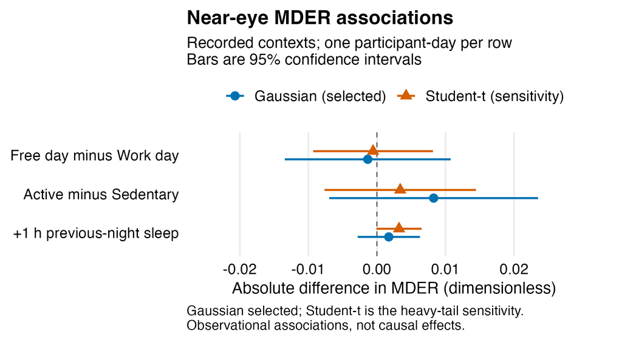

Figure 1: Near-eye primary MDER estimates and mandatory heavy-tail sensitivities. Bars are 95% confidence intervals.

Table 5: Primary near-eye estimates with Gaussian selection and Student-t sensitivity.

| Model | Estimate | 95% CI | Days / participants / sites |
| --- | --- | --- | --- |
| Free day minus Work day |  |  |  |
| Gaussian identity (selected) | −0.0013 | -0.0134 to 0.0108 | 679 / 136 / 9 |
| Student-t identity (sensitivity) | −0.0006 | -0.0093 to 0.0082 | 679 / 136 / 9 |
| Active minus Sedentary |  |  |  |
| Gaussian identity (selected) | 0.0083 | -0.0070 to 0.0235 | 645 / 133 / 9 |
| Student-t identity (sensitivity) | 0.0034 | -0.0076 to 0.0144 | 645 / 133 / 9 |
| +1 h previous-night sleep |  |  |  |
| Gaussian identity (selected) | 0.0017 | -0.0028 to 0.0063 | 679 / 136 / 9 |
| Student-t identity (sensitivity) | 0.0032 | -0.0001 to 0.0065 | 679 / 136 / 9 |

The Student-t estimates moved by 0.125, 0.628, and 0.645 primary Gaussian standard errors for work/free, activity, and sleep, respectively. All shifts were below the prespecified one-standard-error stability threshold, and all Student-t intervals also included zero.

# 6 Raw tests and incomplete multiplicity families

Table 6: Raw MDER-slot tests; no BH-adjusted decision is available.

| Test | Raw p | BH-adjusted p | Status |
| --- | --- | --- | --- |
| Free day minus Work day |  |  |  |
| Common association | 0.830 | — | 1 of 15 slots; no decision |
| Predictor-by-site heterogeneity | 0.005 | — | 1 of 15 slots; no decision |
| Active minus Sedentary |  |  |  |
| Common association | 0.275 | — | 1 of 15 slots; no decision |
| Predictor-by-site heterogeneity | 0.053 | — | 1 of 15 slots; no decision |
| +1 h previous-night sleep |  |  |  |
| Common association | 0.483 | — | 1 of 15 slots; no decision |
| Predictor-by-site heterogeneity | 0.778 | — | 1 of 15 slots; no decision |

The raw common-association p-values were 0.830, 0.275, and 0.483. The raw heterogeneity p-values were 0.005, 0.053, and 0.778. None is a multiplicity- adjusted finding. For each activated predictor, association and heterogeneity are separate named 15-metric BH vectors, and the gap-timing-unaware dataset has its own separate vectors. Only the MDER slot is available in this amendment; the other 14 slots are explicitly retained as unavailable, not silently removed. Consequently, every adjusted value and every adjusted decision is missing by design. No raw p-value is bolded or promoted to a primary decision.

# 7 Family and residual diagnostics

Table 7: Primary near-eye family diagnostics and sensitivity disposition.

| Predictor | Gaussian Q-Q r | \|residual\|-fitted rho | \|standardized residual\| > 4 | Student-t df | Student-t Q-Q r | Assessment |
| --- | --- | --- | --- | --- | --- | --- |
| Free day minus Work day | 0.879 | 0.072 | 0.003 | 3.690 | 0.997 | Acceptable with heavy-tail limitation |
| Active minus Sedentary | 0.870 | 0.102 | 0.003 | 3.915 | 0.997 | Acceptable with heavy-tail limitation |
| +1 h previous-night sleep | 0.879 | 0.076 | 0.003 | 3.607 | 0.997 | Acceptable with heavy-tail limitation |

All selected Gaussian and Student-t models converged, had positive-definite Hessians, finite coefficients and standard errors, and nonsingular participant random intercepts. Gaussian spread trends, extreme-residual fractions, and physical-bound checks passed, but Gaussian Q–Q correlations of 0.870–0.879 failed the nominal 0.95 normal-tail rule. The Student-t quantile-residual Q–Q correlations were 0.997. The Gaussian identity model is therefore reportable only with the explicit heavy-tail limitation and mandatory Student-t sensitivity; Gaussian adequacy is not claimed.

# 8 Actual-date temporal check

Table 8: Primary near-eye actual-date residual screen and gap-aware AR(1) counterpart.

| Predictor | One-day pairs | Participants with pair | Pooled lag-1 r | Maximum site \|r\| | AR(1) rho | Effect shift (primary SE) | Assessment |
| --- | --- | --- | --- | --- | --- | --- | --- |
| Free day minus Work day | 489 | 125 | −0.182 | 0.393 | −0.742 | 0.056 | Stable sensitivity; structured-covariance singularity flagged |
| Active minus Sedentary | 456 | 119 | −0.185 | 0.392 | −0.706 | 0.020 | Stable sensitivity; structured-covariance singularity flagged |
| +1 h previous-night sleep | 489 | 125 | −0.180 | 0.391 | −0.757 | 0.015 | Stable sensitivity; structured-covariance singularity flagged |

Each primary frame exceeded 100 true one-day pairs and 20 participants. The pooled correlations were below 0.20 in absolute value, but site maxima near 0.39 crossed the 0.30 trigger, so actual-date, gap-aware AR(1) counterparts were fitted. They converged with positive-definite Hessians, absolute rho below 0.95, and changed the associations by only 0.015–0.056 primary standard errors.

The automated structured-covariance singularity diagnostic was `TRUE` for all three AR(1) counterparts even though the participant and AR standard deviations were finite. These models are therefore retained only as temporal- stability sensitivities, not promoted as preferred primary models. The tiny effect shifts support stability of the reported primary magnitudes, but no claim of a fully adequate AR generative model is made.

# 9 Influence and site heterogeneity

Table 9: Primary near-eye deletion diagnostics and claim disposition.

| Predictor | Maximum participant shift (SE) | Participant reversals | Maximum site shift (SE) | Most influential site | Site reversals | Disposition |
| --- | --- | --- | --- | --- | --- | --- |
| Free day minus Work day | 0.53 | 4 | 1.22 | IZTECH | 3 | Magnitude reportable; cross-site direction unstable |
| Active minus Sedentary | 0.71 | 0 | 1.14 | BAUA | 0 | Magnitude reportable; site generality limited |
| +1 h previous-night sleep | 0.30 | 0 | 1.05 | IZTECH | 1 | Magnitude reportable; cross-site direction unstable |

All 405 participant deletions and 27 site deletions fitted without failure. Maximum participant shifts were below one primary standard error. Site shifts were between 1.05 and 1.22 standard errors, which limits generality. The work/free estimate reversed under deletion of KNUST, MPI, or RISE; the sleep estimate reversed after deleting IZTECH. Their magnitudes and intervals are reportable, but their cross-site directions are not stable. Activity had no participant or site reversal, so its association estimate is reportable with the stated site-influence and heavy-tail limitations.

The descriptive site-specific work/free estimates ranged from -0.0703 at KNUST to 0.0460 at IZTECH; activity ranged from -0.0381 at BAUA to 0.0818 at KNUST; and sleep ranged from -0.0063 per hour at RISE to 0.0081 at IZTECH. These are unadjusted heterogeneity descriptions, not separately tested site claims.

# 10 Registered benchmark

Table 10: Exact registered random-site/random-slope benchmark disposition.

| Predictor | Formula | Maximum \|site correlation\| | Converged | Singular | Disposition |
| --- | --- | --- | --- | --- | --- |
| Free day minus Work day | response_value ~ work_free_day + (work_free_day \| site) + (1 \| site:participant_key) | 0.558 | Yes | No | Estimable benchmark only |
| Active minus Sedentary | response_value ~ activity_status + (activity_status \| site) + (1 \| site:participant_key) | 0.393 | Yes | No | Estimable benchmark only |
| +1 h previous-night sleep | response_value ~ previous_sleep_duration_centered_h + (previous_sleep_duration_centered_h \| site) + (1 \| site:participant_key) | 1.000 | No | Yes | Non-estimable |

The exact work/free and activity benchmarks were estimable but remain benchmarks only. The sleep benchmark was singular, had a random-site correlation at 1.000, and was classified non-estimable. It was not simplified post hoc. The fixed-site route is the approved primary structure for the nine submitted sites.

# 11 Placement, paired/common, and dataset comparisons

Table 11: Selected Gaussian placement estimates in the primary dataset.

| Placement | Contrast | Estimate | 95% CI | Days / participants / sites |
| --- | --- | --- | --- | --- |
| All available |  |  |  |  |
| Near eye | Free day minus Work day | −0.0013 | -0.0134 to 0.0108 | 679 / 136 / 9 |
| Chest | Free day minus Work day | −0.0073 | -0.0211 to 0.0064 | 709 / 151 / 8 |
| Near eye | Active minus Sedentary | 0.0083 | -0.0070 to 0.0235 | 645 / 133 / 9 |
| Chest | Active minus Sedentary | 0.0062 | -0.0105 to 0.0229 | 669 / 147 / 8 |
| Near eye | +1 h previous-night sleep | 0.0017 | -0.0028 to 0.0063 | 679 / 136 / 9 |
| Chest | +1 h previous-night sleep | 0.0020 | -0.0033 to 0.0073 | 709 / 151 / 8 |
| Paired/common |  |  |  |  |
| Near eye | Free day minus Work day | 0.0009 | -0.0156 to 0.0175 | 469 / 106 / 8 |
| Chest | Free day minus Work day | 0.0009 | -0.0132 to 0.0150 | 469 / 106 / 8 |
| Near eye | Active minus Sedentary | 0.0094 | -0.0104 to 0.0292 | 444 / 104 / 8 |
| Chest | Active minus Sedentary | 0.0039 | -0.0130 to 0.0207 | 444 / 104 / 8 |
| Near eye | +1 h previous-night sleep | 0.0005 | -0.0055 to 0.0066 | 469 / 106 / 8 |
| Chest | +1 h previous-night sleep | 0.0035 | -0.0018 to 0.0088 | 469 / 106 / 8 |

All all-available and paired/common placement intervals included zero. The paired/common work/free estimates were nearly identical near eye and at the chest; activity and sleep estimates varied modestly by placement but remained interval-compatible with zero. These are complementary placement analyses, not replacements for near-eye primary.

Table 12: Near-eye primary versus gap-timing-unaware estimates on all-available and dataset-common samples.

| Dataset | Contrast | Estimate | 95% CI | Days / participants / sites |
| --- | --- | --- | --- | --- |
| All available |  |  |  |  |
| Primary | Free day minus Work day | −0.0013 | -0.0134 to 0.0108 | 679 / 136 / 9 |
| Gap-timing-unaware | Free day minus Work day | −0.0016 | -0.0140 to 0.0108 | 664 / 136 / 9 |
| Primary | Active minus Sedentary | 0.0083 | -0.0070 to 0.0235 | 645 / 133 / 9 |
| Gap-timing-unaware | Active minus Sedentary | 0.0090 | -0.0066 to 0.0246 | 630 / 133 / 9 |
| Primary | +1 h previous-night sleep | 0.0017 | -0.0028 to 0.0063 | 679 / 136 / 9 |
| Gap-timing-unaware | +1 h previous-night sleep | 0.0018 | -0.0028 to 0.0065 | 664 / 136 / 9 |
| Primary/gap common |  |  |  |  |
| Primary | Free day minus Work day | −0.0014 | -0.0138 to 0.0110 | 664 / 136 / 9 |
| Gap-timing-unaware | Free day minus Work day | −0.0016 | -0.0140 to 0.0108 | 664 / 136 / 9 |
| Primary | Active minus Sedentary | 0.0094 | -0.0062 to 0.0250 | 630 / 133 / 9 |
| Gap-timing-unaware | Active minus Sedentary | 0.0090 | -0.0066 to 0.0246 | 630 / 133 / 9 |
| Primary | +1 h previous-night sleep | 0.0017 | -0.0029 to 0.0064 | 664 / 136 / 9 |
| Gap-timing-unaware | +1 h previous-night sleep | 0.0018 | -0.0028 to 0.0065 | 664 / 136 / 9 |

On all available repaired near-eye days, the Gaussian estimates were -0.0016 for work/free (95% CI -0.0140 to 0.0108), 0.0090 for activity (-0.0066 to 0.0246), and 0.0018 per hour of previous-night sleep (-0.0028 to 0.0065). All three intervals include zero. The exact primary–gap common samples contain 664 work/free and sleep days and 630 activity days; on those rows the primary and gap estimates differ by at most 0.0004 MDER.

Table 13: Repaired gap near-eye estimates and mandatory heavy-tail sensitivities.

| Model | Estimate | 95% CI | Days / participants / sites |
| --- | --- | --- | --- |
| Free day minus Work day |  |  |  |
| Gaussian identity (selected) | −0.001619 | -0.014015 to 0.010777 | 664 / 136 / 9 |
| Student-t identity (sensitivity) | −0.000915 | -0.009891 to 0.008061 | 664 / 136 / 9 |
| Active minus Sedentary |  |  |  |
| Gaussian identity (selected) | 0.009020 | -0.006576 to 0.024617 | 630 / 133 / 9 |
| Student-t identity (sensitivity) | 0.004698 | -0.006555 to 0.015951 | 630 / 133 / 9 |
| +1 h previous-night sleep |  |  |  |
| Gaussian identity (selected) | 0.001818 | -0.002816 to 0.006452 | 664 / 136 / 9 |
| Student-t identity (sensitivity) | 0.003357 | 0.000003 to 0.006710 | 664 / 136 / 9 |

The Student-t shifts were 0.111, 0.543, and 0.651 Gaussian standard errors, all below the prespecified one-standard-error threshold. The Student-t sleep interval was 0.000003 to 0.006710, only just above zero; the corresponding selected Gaussian interval includes zero. This tail-model sensitivity is disclosed explicitly and does not create a BH-adjusted finding.

Table 14: Repaired gap MDER-slot raw tests; no BH-adjusted decision is available.

| Test | Raw p | BH-adjusted p | Status |
| --- | --- | --- | --- |
| Free day minus Work day |  |  |  |
| Common association | 0.804 | — | 1 of 15 slots; no decision |
| Predictor-by-site heterogeneity | 0.005 | — | 1 of 15 slots; no decision |
| Active minus Sedentary |  |  |  |
| Common association | 0.245 | — | 1 of 15 slots; no decision |
| Predictor-by-site heterogeneity | 0.046 | — | 1 of 15 slots; no decision |
| +1 h previous-night sleep |  |  |  |
| Common association | 0.470 | — | 1 of 15 slots; no decision |
| Predictor-by-site heterogeneity | 0.808 | — | 1 of 15 slots; no decision |

The repaired gap raw common-association p-values are 0.804, 0.245, and 0.470. The raw heterogeneity p-values are 0.005, 0.046, and 0.808. The work/free and activity heterogeneity values are nominal raw signals only: their 15-slot heterogeneity families remain incomplete, so neither has an adjusted p-value or an inferential decision.

Table 15: Repaired gap near-eye residual, Student-t, and actual-date AR(1) checks.

| Predictor | Gaussian Q-Q r | \|residual\|-fitted rho | Student-t Q-Q r | One-day pairs / participants | Pooled lag-1 r | Maximum site \|r\| | AR(1) rho | AR effect shift (SE) | Assessment |
| --- | --- | --- | --- | --- | --- | --- | --- | --- | --- |
| Free day minus Work day | 0.880 | 0.060 | 0.997 | 466 / 124 | −0.189 | 0.399 | −0.718 | 0.061 | Acceptable stability sensitivity; covariance singularity flagged |
| Active minus Sedentary | 0.870 | 0.091 | 0.996 | 433 / 118 | −0.192 | 0.396 | −0.685 | 0.023 | Acceptable stability sensitivity; covariance singularity flagged |
| +1 h previous-night sleep | 0.879 | 0.068 | 0.997 | 466 / 124 | −0.187 | 0.390 | −0.734 | 0.019 | Acceptable stability sensitivity; covariance singularity flagged |

All repaired gap Gaussian and Student-t fits passed convergence, spread, extreme-residual, bounds, and sensitivity rules. Gaussian Q–Q correlations of 0.870–0.880 retain the same heavy-tail limitation as the primary route; Student-t Q–Q correlations were 0.996–0.997. Site lag maxima triggered all three actual-date AR(1) counterparts. Their rho values ranged from -0.734 to -0.685, they shifted estimates by only 0.019–0.061 Gaussian standard errors, and they carry the structured-covariance singularity flag. They remain stability sensitivities only. The exact registered gap sleep benchmark is non-estimable because its random-site correlation reached 1.000; it was not simplified post hoc.

The repaired chest source has no finite nonpositive MDER value. The previous THUAS zero and every other superseded gap result are excluded from this report; the corrected THUAS day is missing under the no-viable-ratio rule.

# 12 Bounded refresh and frozen-result integrity

Table 16: Bounded METRIC-010 gap-refresh execution and preservation record.

| Domain | Observed | Verdict |
| --- | --- | --- |
| Execution scope | 24 affected frames: 18 gap frames and 6 primary-gap common-sample frames | PASS |
| Frozen primary routes | 12 all-available or placement-paired primary frames unchanged | PASS |
| Frozen production results | 12 preservation domains passed | PASS |
| Gap availability | Near eye 687/811; chest 723/897; zero finite nonpositive values | PASS |
| Multiplicity | MDER slot refreshed in each affected 15-slot family; 1/15 available | INCOMPLETE_NO_BH_DECISION |
| Refresh runtime | 9.0 seconds; no bootstrap or resampling | PASS |
| Pre-refresh provenance | Reconstructed output manifest SHA-256 ce5659cf9717f6dafe1fafbba00eb81237fdc436725f1c434c76935f62dc5544 | PASS |

Exactly 24 MDER-dependent frames were refreshed: all 18 gap frames and the six primary–gap common-sample frames whose membership necessarily changes with gap MDER availability. The 12 primary all-available or placement-paired frames are object-identical to their pre-refresh copies. Twelve additional production preservation domains verify unchanged primary estimates, model tests, heterogeneity rows, participant/site deletion results, claim verdicts, and unaffected fitted-model serializations. No primary all-available, placement-paired, or deletion model was refitted; the six primary–gap common-sample fits were necessarily updated.

# 13 Comparison with V0 and the approved hourly analysis

V0 fitted one repeated hourly melEDI outcome and jointly entered context predictors. This amendment fits one dimensionless daily MDER value per admissible participant-day and one predictor-specific model at a time. V0 days with more supported hours contributed more rows; here every admissible MDER day contributes one row. V0 coefficients, p-values, and claims therefore do not map numerically to these estimates.

The approved hourly H06 analysis also remains a separate estimand. This MDER amendment is not its sensitivity analysis and does not replace it.

# 14 Reproducibility and H06-D-G2-MDER-GAP decision record

The family and influence pilots retain their original output manifests. Their historical code manifests pin the task-local contract, data adapter, and modeling helper as they existed at pilot time. The family pilot also pins the then-current frame registry and static output manifest; the influence pilot pins the then-current frame registry. Those shared task-local files changed only for the approved METRIC-010 source/support repin and repair-dependent frames. The exact primary pilot frames and pilot outputs remain unchanged. The report permits precisely these recorded historical mismatches. The current production input manifest additionally retains the 14 pre-refresh output hashes and the prior output-manifest hash as historical inputs. Those paths now correctly differ because the affected artifacts were replaced; their prior manifest is reconstructed byte-for-byte and its identity is verified by the dedicated gap-refresh provenance manifests. All current static, production-output, refresh, and reader hashes match exactly.

The primary H06-D-G2-MDER decisions remain author-approved and unchanged. The corrected gap branch stopped at **H06-D-G2-MDER-GAP**, and the author approved the following items on 2026-08-11:

1. the repaired gap availability and exact predictor-specific samples;
2. the three selected Gaussian gap estimates and their explicit heavy-tail limitation;
3. disclosure that the Student-t sleep interval is only just above zero while the selected Gaussian interval includes zero;
4. treating the raw work/free and activity heterogeneity p-values as non-decisional because their 15-slot BH families remain incomplete;
5. retaining the singularly flagged gap AR(1) fits only as temporal-stability sensitivities and the singular gap sleep random-slope fit as a non-estimable registered benchmark; and
6. the verified preservation of every unaffected primary result, with no primary all-available, placement-paired, or deletion refit.

This approval closes and freezes the corrected MDER-specific branch. It does not authorize the separate H06-D-G2P-AR repair decision, another model fit, the remaining daily-metric production grid, a Stage 3 reader report, preparation companion, site integration, shared preparation change, manuscript edit, commit, or upload.